# Aprendizagem_de_Maquina-2024-08-30

Helena R. S. D’Espindula

2024-08-24

```r
knitr::opts_chunk$set(echo = TRUE)
knitr::opts_chunk$set(class.source = "bg-warning") ## para Python
require(reticulate)
```

# Resumo

1. Instâncias - KNN
2. Naive Bayes - Prob
3. Lineares:
- LDA
- Reg Log
- Perceptron
- SVM
4. Árvores
5. Redes Neurais
6. Ensembler? - RamCom forest?

# Aprendizagem Bayesiana

## Introdução

- O pensamento Bayesiano fornece uma abordagem probabilística para a aprendizagem.
- Está baseado na suposição de que as quantidades de interesse são reguladas por distribuições de probabilidades.
- Quantificar o custo/benefício entre diferentes decisões de classificação usando probabilidades e custos associados a classificação.
- Teorema de Bayes: Mostra como alterar as probabilidades a priori tendo em conta novas evidências de forma a obter probabilidades a posteriori.

## Terminologia

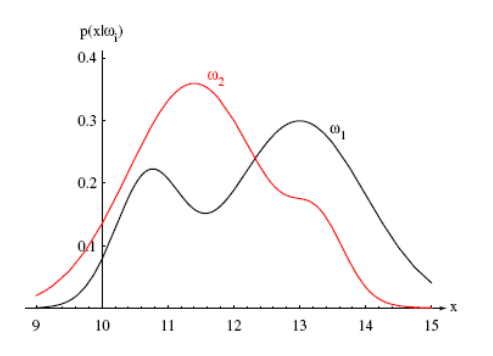

Fig01

- Densidade de duas classes em que x representa uma característica qualquer.
- Probabilidade a posteriori
  - P(ωj |x)
  - Probabilidade que o padrão pertença a classe ωj data a característica x
- Regra de decisão baseada apenas em priors
  - ω1, se P(ω1) > P(ω2)
  - ω2, caso contrário

[…]

### Exemplo

- Um médico sabe que a meningite causa torcicolo em 50% dos casos. Porém, o médico sabe que a meningite atinge 1/50000 e também que a probabilidade de se ter torcicolo é de 1/20.
- Usando Bayes pra saber a probabilidade de uma pessoa ter meningite dado que ela está com torcicolo

Temos então: $P(T |M) = 0.5$ $P(M) = 1/50000$ $P(T ) = 1/20$

$$P(M|T ) = \frac{P(M) \times P(T |M)}{P(T)} = \frac{1/50000
\times 0.5}{1/20} = 0.0002$$

[…]

## Classificador Naïve Bayes

- Um dos algoritmos de aprendizagem mais práticos e utilizados na literatura.
- Denominado Naïve (ingênuo) por assumir que os atributos são condicionalmente independentes, ou seja, a informação de um evento não é informativa sobre nenhum outro.
- Apesar dessa premissa, o classificador reporta bom desempenho em diversas tarefas de classificação. Aplicações bem sucedidas:
  - Diagnóstico
  - Classificação de documentos textuais
- Se aplica a tarefas de aprendizagem onde cada instância x é descrita por um conjunção de valores de atributos em que a função alvo, f (x) pode assumir qualquer valor de um conjunto V .
- Um conjunto de exemplos de treinamento da função alvo é fornecido a uma nova instância é apresentada, descrita pela tupla de valores de atributos < a1, a2, . . . , an >.
- A tarefa é predizer o valor alvo (ou classificação) para esta nova instância.
- O classificador é baseado na suposição de que os valores dos atributos são condicionalmente independentes dados o valor alvo.
- Se usarmos Bayes para múltiplas evidências, temos
  $$P(H|E1, E2, . . . , En) = \frac{P(E1, E2, . . . , En|H)
  \times P(H)}{P(E1, E2, . . . , En)}$$
- Considerando a hipótese de independência, podemos re-escrever o teorema de Bayes da seguinte forma:
  $$P(H|E1, E2, . . . , En) = \frac{P(E1|H)\times , P(E2|H)\times , . . . ,
  P(En|H) \times P(H)}{P(E1, E2, . . . , En)}$$

O denominador pode ser ignorado por se tratar de um termo comum.

### Exemplo

Para entender melhor o considere o seguinte problema

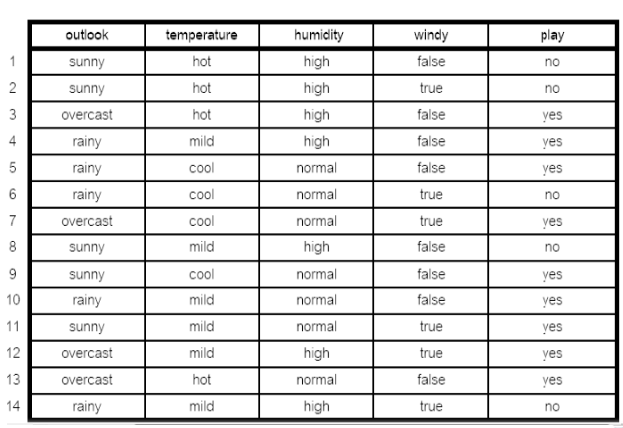

Instância em execusão

#### Construindo o Modelo (NB)

O primeiro passo consiste em construir o modelo de probabilidades condicionais Naïve Bayes (NB)

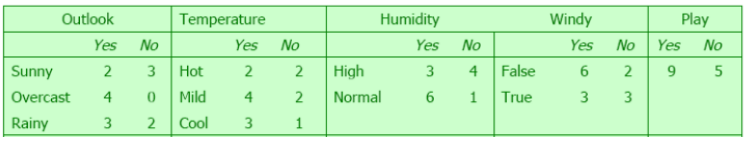

Instância em execusão

- A tabela acima contem a frequência de diferentes evidências.
- Por exemplo, existem duas instâncias mostrando (outlook=sunny) para (jogar=yes)

Após definir todas as frequências é necessário calcular todas as probabilidades condicionais e as probabilidades a priori

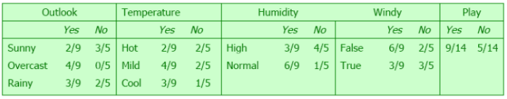

Instância em execusão

Por exemplo:

- $P(outlook=sunny|play=yes) = 2/9$
- $P(play=yes) = 9/14$

#### Predição

- De posse do modelo, podemos usá-lo para predizer um evento “play” com base em um conjunto qualquer de evidências.
- Por exemplo: [Sunny,Cool,High,True,?]
  $$P(Yes|E ) = (P(Outlook = sunny |Yes) \times
  P(Temp = Cool|Yes) \times
  P(Humidity = High|Yes) \times
  P(Windy = True|Yes) \times
  P(Yes))/P(E )$$

P(E) pode ser ignorada por se tratar de um denominador comum quando queremos comparar as duas classes. Deste modo, temos

$$P(Yes|E ) = 2/9 \times 3/9 \times 3/9 \times 3/9 \times 9/14$$

## Técnica de Suavização

- Em alguns casos, a frequência pode ser zero, como por exemplo $P(outlook=overcast|play=No) = 0/5$.
- Isso cria um problema para calcular P(No), a qual será sempre zero quando esta evidência for utilizada.
- A técnica de suavização mais utilizada é a estimação de Laplace, a qual é dada

$$P′(H|E ) = \frac{nc + μp}{n + μ}$$

- $n_c$ é o número de hipóteses existentes para a classe (Ex: Zero para outlook=overcast e play=no)
- $n$ número e exemplos totais para o treinamento
- $μ$ número de exemplos virtuais Considerado que as evidências são igualmente distribuídas, tempo $p = 1/3$ (sunny,overcast,rainy)

Reestimando os valores usando Laplace, teriamos:

- $P(outlook = Sunny |play = No) = \frac{3+3\times 1/3}{5+3} = 4/8$
- $P(outlook = Overcast|play = No) = \frac{0+3\times 1/3}{5+3} = 1/8$
- $P(outlook = Rainy |play = No) = \frac{2+3\times 1/3}{5+3} = 3/8$

Desta forma, todos os valores foram redistribuídos mantendo uma proporção similar

## Calculando as probabilidade para atributos contínuos

Existem duas maneiras:

- Discretizar os atributos continuos em algumas categorias. Por exemplo, temperatura acima de 80F pode ser considerada alta.
- Outra forma consiste em usar uma função de densidade probabilidade e desta forma preservar os valores continuos.
  - Nesse caso assumimos que as variáveis continuas seguem uma distribuição normal
  - Com isso em mente, podemos calcular a média e desvio de cada variável usando a base de aprendizagem.
  - De posse da média e desvio, basta aplicar a formula da normal para estimar a probabilidade

$$f (x) = \frac{1}{\sigma \sqrt{2 \pi}} e^{− \frac{(x−μ)^2}{2 \sigma^2}}$$

- scipy.stats.norm(μ, σ).pdf (x)

[…]

Exercício:

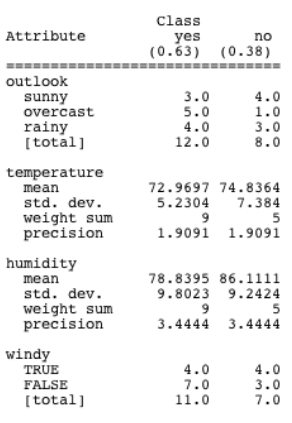

Instância em execusão

Calcular a probabilidade para: $E =[Outlook=rainy, Temp=65, Humid=70, Wind=True)$ $P(Yes|E) = ?$ $P(No|E) = ?$

Resposta:

Temperatura se No: - Valor interesse = 65 = $x$ - Media = 74,8364 = $\mu$ - SD = 7,384 = $\sigma$

$$f (x) = \frac{1}{\sigma \sqrt{2 \pi}} e^{− \frac{(x−μ)^2}{2 \sigma^2}}$$

$$f (x) = \frac{1}{7,384 \sqrt{2 \pi}} e^{− \frac{(65−74.8364)^2}{2 \times
7,384^2}}$$
$$f(x) = 0,0222474$$

[figure not shown]

Instância em execusão

$P(Yes|E) = 4/12 \times 0.023 \times 0.0271 \times 4/11 \times 0.63 = 0.75$

$P(No|E) = 3/8 \times 0.022 \times 0.0094 \times 4/7 \times 0.38 = 0.25$

# Classificadores Lineares

Introdução A combinação linear das características é utilizada para tomar uma decisão Classificadores de rápido treinamento que em muitos casos atingem bom desempenho.

$$y = f(w \cdot x + b) = f (\sum_j{w_j x_j + b)}$$

Durante o treinamento, os algoritmos desta categoria devem encontrar $(w)$ que melhor separa os dados. As fronteiras de decisão são lineares (reta, plano, hiperplano)

**Combinando classificicadores lineares é possivel resolver problema que não é linearmente separaveis**

- Existem duas classes de métodos para determinar os parâmetros de um classificador.
- Generativos: Levam em consideração da distribuição dos dados P(⃗x|classe) (função de densidade condicional). Ou seja, leva em consideração como os dados foram gerados para então realizar a classificação
  - Linear Discriminant Analysis
- Discriminativos: A distribuição dos dados não é levada em consideração.
  - Regressão logistica
  - Perceptron
  - SVM